This is an example of a Stan model I fit for my research as a graduate assistant. The data is the number (frequency) of people censored in China that were censored zero times, one time, two times,… (count). The task is to find this univariate distribution.

This document was produced though Rmarkdown and knitr.

```r
library(rstan)
options(mc.cores = parallel::detectCores())
rstan_options(auto_write = TRUE)

library(ggplot2)
library(cowplot)
```

First take a quick look at the dataset.

```r
user <- read.csv('user_counts.csv')

head(user)
```

```
##   count     freq
## 1     0 13808789
## 2     1     4155
## 3     2     1679
## 4     3      949
## 5     4      614
## 6     5      478
```

```r
str(user)
```

```
## 'data.frame':    131 obs. of  2 variables:
##  $ count: int  0 1 2 3 4 5 6 7 8 9 ...
##  $ freq : int  13808789 4155 1679 949 614 478 335 294 258 225 ...
```

And a graph of freq~count, and then log(freq)~log(count), with the first point removed, as it is so much larger than the rest.

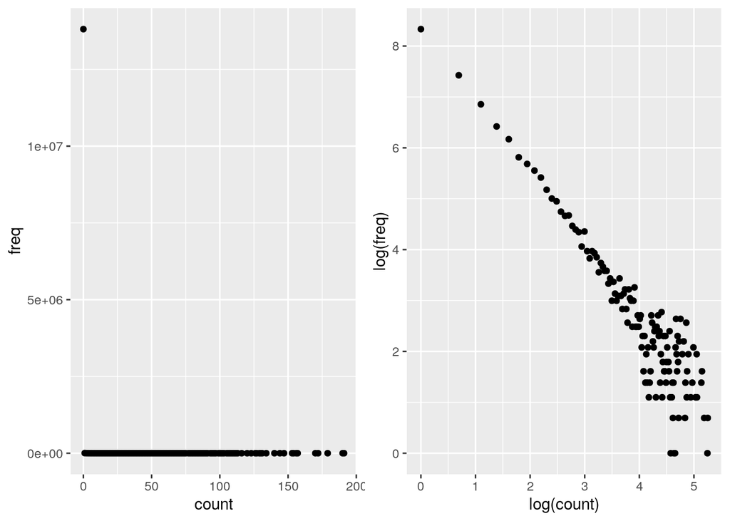

```r
p1 <- ggplot(user)+
  geom_point(aes(count,freq))
p2 <- ggplot(user[-1,])+
  geom_point(aes(log(count),log(freq)))

plot_grid(p1, p2, align = "h", ncol = 2)
```

The data appear to be governed by the power law, but with the first point excluded, as we have a very large value for count=0, freq=13808789

The following code was written directly in Stan because the high level interface Brms doesn’t have the family power law, and it needs to be a hurdle model.

Our code is then:

```r
code <- "
functions {
  //this is the core function
  //it is the power law distribution
  //on 1 to 200

  real power_lpmf(int y, real alpha){
    real normalize = 0;
    for (n in 1:200) normalize += pow(n,alpha);
    return alpha * log(y) - log(normalize);
  }

  //And this function applies the hurdle model to it
  real hurdle_power_lpmf(int y, real alpha, real theta) {
    if (y == 0) {
      return bernoulli_lpmf(1 | theta);
    } else {
      return bernoulli_lpmf(0 | theta) +
             power_lpmf(y | alpha);
    }
  }
}

data {
  int<lower=0> N;  //number of points
  int<lower=0> f[N]; //frequency
  int<lower=0> c[N]; //count
}

transformed data {
  int fsum = sum(f); //for generating random numbers
}

parameters {
  real <upper=0> alpha;
  real <lower=0,upper=1> theta;
}

model {
  // priors. We know the probability of zero is high.
  // And we know alpha should be close to zero.
  // We use a half normal prior from -infty to 0.

  theta ~ beta(10, 1);
  alpha ~ normal(0,1) T[,0]; // T sets support.

  // for the model itself, each value for count is weighed by
  // the frequency for that count. This is a sufficient statistic.

  for(n in 1:N) {
    target += f[n] * hurdle_power_lpmf(c[n]|alpha, theta);
  }
}

generated quantities{
  // for model testing we want a  consider each value count a
  // binomial experiment with hurdle power probability.
  // this is an easy way to get a sample from a discrete
  // custom variable.

  int freq_test[N];
  for(n in 1:N) {
    freq_test[n] = binomial_rng(fsum,exp(hurdle_power_lpmf(c[n]|alpha, theta)));
  }
}
"

data = list(N=nrow(user),f=user$freq,c=user$count)

fit = stan(model_code=code,data=data)
saveRDS(fit, "power.rds")
```

Usually it is a good idea to save your models after you make them. Lets take a look at the model now.

```r
print(fit,digits=5,pars=c('alpha','theta'))
```

```
## Inference for Stan model: 5df7ac3d26554c578af16ac28697f902.
## 4 chains, each with iter=2000; warmup=1000; thin=1;
## post-warmup draws per chain=1000, total post-warmup draws=4000.
##
##           mean se_mean      sd     2.5%      25%      50%      75%    97.5%
## alpha -1.43930   1e-04 0.00641 -1.45203 -1.44362 -1.43935 -1.43493 -1.42663
## theta  0.99915   0e+00 0.00001  0.99914  0.99915  0.99915  0.99916  0.99917
##       n_eff    Rhat
## alpha  3974 0.99921
## theta  2889 1.00130
##
## Samples were drawn using NUTS(diag_e) at Fri May 29 17:22:00 2020.
## For each parameter, n_eff is a crude measure of effective sample size,
## and Rhat is the potential scale reduction factor on split chains (at
## convergence, Rhat=1).
```

The model looks pretty good. R hat values are < 1.1 and n_eff is high. The pairs plot should also show us if there are any problems.

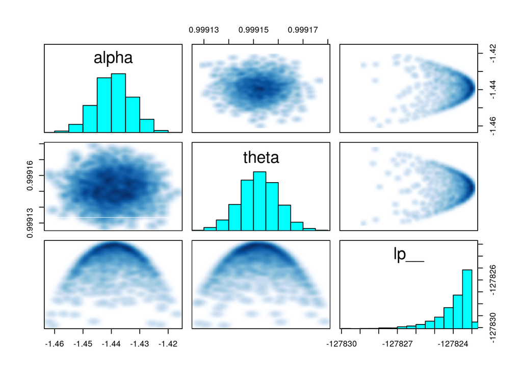

```r
pairs(fit,pars=c('alpha','theta','lp__'))
```

All looks good, we have nice normal looking posteriors for the model parameters. And the log probability shows a nice skewed left distribtion. This is because the Hamiltonian Sampler Stan uses gets closer and closer to the best fitting parameters.

We extract the random sample and take the posterior predictive mean.

```r
freq <- extract(fit,par='freq_test')
freq <- data.frame(freq)
test <- colMeans(freq)
```

Compare count=0 for observed vs predicted:

```r
print(paste0('Actual:',user$freq[1]));print(paste0('Predicted:',test[1]))
```

```
## [1] "Actual:13808789"
```

```
## [1] "Predicted:13808791.441"
```

Very accurate. Now lets graph the rest of the points.

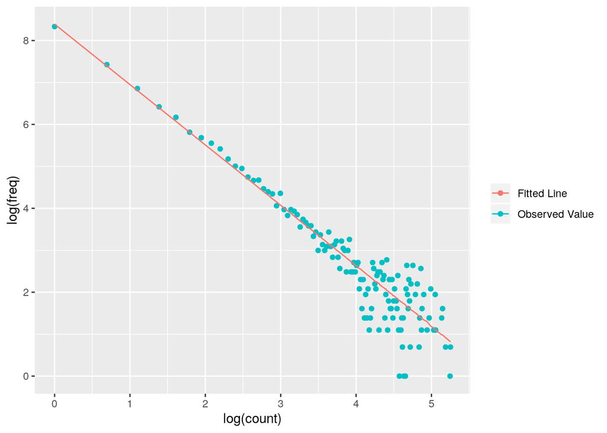

```r
ggplot(user[-1,])+
  geom_point(aes(log(count),log(freq),color='Observed Value'))+
  geom_line(aes(log(count),log(test[-1]),color='Fitted Line'))+
  labs(color=NULL)
```

Our model visually fits pretty good. So for our model, we first get the constant for the power law distribution. And we also invert it to put it on the bottom of the fraction.

```r
alpha <- mean(extract(fit,par='alpha')[[1]])
theta <- mean(extract(fit,par='theta')[[1]])

support <- 1:200
constant <- (1-theta)/sum(support^alpha)
constant <- 1/constant
alpha <- round(alpha,3)
theta <- round(theta,5)
constant <- round(constant,3)
```

Our final model is then:

$$\begin{align}
\text{HurdlePowerLaw}(n) &= \begin{cases}
0.99915, & \text{if $n=0$} \\
\frac{n^{-1.439}}{3140.867}, & \text{if $1 \leq n \leq 200$} \nonumber
\end{cases}
\end{align}$$

The caveat for this is also that the variance around this line increases as count increases. But our model appears to be mostly unbiased, at the end there appear to be more points below the line, and in the middle there appear to be more points above the line, so it isn’t completely unbiased.

We could go on to model the increase in variance. We could also do some other model cheking, but the brunt of the model looks to be good. We could also make some simpler models and compare WAIC’s, get a pseudo-R squared, etc.